# Chronic Kidney Disease - Logistic Regression Step-by-Step Training

Somnath Chaudhuri

November 10, 2025

# Introduction

This comprehensive training document demonstrates a step-by-step approach to building logistic regression models for predicting Chronic Kidney Disease (CKD). We will progress from basic univariate models to sophisticated multivariate models, covering data exploration, preprocessing, feature selection, model building, and evaluation.

# Step 1: Data Loading and Initial Exploration

```r
# Load the Chronic Kidney Disease dataset
ckd_data <- readARFF("F:/NCRM/Data/chronic_kidney_disease_full.arff")

# Define column names based on dataset documentation
column_names <- c(
  "age", "blood_pressure", "specific_gravity", "albumin", "sugar",
  "red_blood_cells", "pus_cell", "pus_cell_clumps", "bacteria",
  "blood_glucose_random", "blood_urea", "serum_creatinine", "sodium",
  "potassium", "hemoglobin", "packed_cell_volume", "white_blood_cell_count",
  "red_blood_cell_count", "hypertension", "diabetes_mellitus",
  "coronary_artery_disease", "appetite", "peda_edema", "anemia", "class"
)

# Assign column names
colnames(ckd_data) <- column_names

# Clean column names for safe reference
colnames(ckd_data) <- make.names(colnames(ckd_data))

# Convert outcome variable to binary factor (1 = CKD, 0 = No CKD)
ckd_data <- ckd_data %>%
  mutate(
    ckd_status = ifelse(class == "ckd", 1, 0),
    ckd_status = as.factor(ckd_status)
  )

# Initial data exploration
cat("Dataset Dimensions:", dim(ckd_data), "\n")
```

```
## Dataset Dimensions: 400 26
```

```r
cat("CKD Status Distribution:\n")
```

```
## CKD Status Distribution:
```

```r
print(table(ckd_data$ckd_status))
```

```
##
##   0   1
## 149 246
```

```r
cat("Proportions:\n")
```

```
## Proportions:
```

```r
print(prop.table(table(ckd_data$ckd_status)))
```

```
##
##         0         1
## 0.3772152 0.6227848
```

The dataset contains 400 observations with 25 clinical variables. The outcome variable shows class distribution that we will use for binary classification.

# Step 2: Comprehensive Data Quality Assessment

```r
missing_plot <- gg_miss_var(ckd_data) +
  theme_minimal() +
  labs(title = "Missing Values Pattern by Variable")

missing_summary <- miss_var_summary(ckd_data)
print("Missing Value Summary:")
```

```
## [1] "Missing Value Summary:"
```

```r
print(missing_summary)
```

```
## # A tibble: 26 × 3
##    variable               n_miss pct_miss
##    <chr>                   <int>    <num>
##  1 red_blood_cells           152     38
##  2 red_blood_cell_count      131     32.8
##  3 white_blood_cell_count    108     27
##  4 potassium                  88     22
##  5 sodium                     87     21.8
##  6 packed_cell_volume         72     18
##  7 pus_cell                   65     16.2
##  8 hemoglobin                 52     13
##  9 sugar                      49     12.2
## 10 specific_gravity           47     11.8
## # ℹ 16 more rows
```

```r
cat("\nData Types Summary:\n")
```

```
##
## Data Types Summary:
```

```r
str(ckd_data[, 1:10])
```

```
## 'data.frame':    400 obs. of  10 variables:
##  $ age                 : num  48 7 62 48 51 60 68 24 52 53 ...
##  $ blood_pressure      : num  80 50 80 70 80 90 70 NA 100 90 ...
##  $ specific_gravity    : Factor w/ 5 levels "1.005","1.010",..: 4 4 2 1 2 3 2 3 3 4 ...
##  $ albumin             : Factor w/ 6 levels "0","1","2","3",..: 2 5 3 5 3 4 1 3 4 3 ...
##  $ sugar               : Factor w/ 6 levels "0","1","2","3",..: 1 1 4 1 1 1 1 5 1 1 ...
##  $ red_blood_cells     : Factor w/ 2 levels "normal","abnormal": NA NA 1 1 1 NA NA 1 1 2 ...
##  $ pus_cell            : Factor w/ 2 levels "normal","abnormal": 1 1 1 2 1 NA 1 2 2 2 ...
##  $ pus_cell_clumps     : Factor w/ 2 levels "present","notpresent": 2 2 2 1 2 2 2 2 1 1 ...
##  $ bacteria            : Factor w/ 2 levels "present","notpresent": 2 2 2 2 2 2 2 2 2 2 ...
##  $ blood_glucose_random: num  121 NA 423 117 106 74 100 410 138 70 ...
```

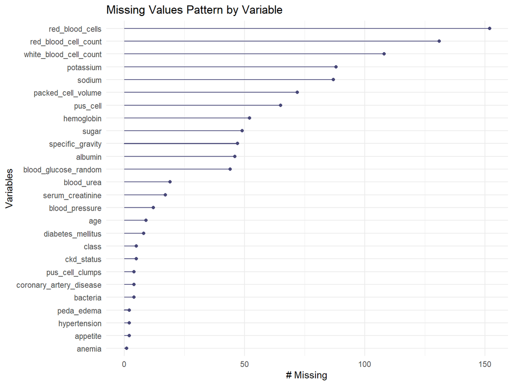

```r
numerical_vars <- c("age", "blood_pressure", "specific_gravity", "albumin", "sugar",
                   "blood_glucose_random", "blood_urea", "serum_creatinine", "sodium",
                   "potassium", "hemoglobin", "packed_cell_volume",
                   "white_blood_cell_count", "red_blood_cell_count")

categorical_vars <- c("red_blood_cells", "pus_cell", "pus_cell_clumps", "bacteria",
                     "hypertension", "diabetes_mellitus", "coronary_artery_disease",
                     "appetite", "peda_edema", "anemia")

ckd_data <- ckd_data %>%
  mutate(across(all_of(numerical_vars), as.numeric)) %>%
  mutate(across(all_of(categorical_vars), as.factor))

missing_plot
```

Several variables have missing values requiring imputation. We’ll use appropriate methods based on variable types and missingness patterns.

# Step 3: Data Preprocessing and Imputation

```r
ckd_clean <- ckd_data[!is.na(ckd_data$class), ]

# cat("Missing data pattern:\n")
# md.pattern(ckd_clean[, c(numerical_vars, categorical_vars)], plot = FALSE)

for (var in numerical_vars) {
  if (any(is.na(ckd_clean[[var]]))) {
    median_val <- median(ckd_clean[[var]], na.rm = TRUE)
    ckd_clean[[var]][is.na(ckd_clean[[var]])] <- median_val
    cat("Imputed", var, "with median:", median_val, "\n")
  }
}
```

```
## Imputed age with median: 54
## Imputed blood_pressure with median: 80
## Imputed specific_gravity with median: 4
## Imputed albumin with median: 1
## Imputed sugar with median: 1
## Imputed blood_glucose_random with median: 121
## Imputed blood_urea with median: 42
## Imputed serum_creatinine with median: 1.3
## Imputed sodium with median: 138
## Imputed potassium with median: 4.4
## Imputed hemoglobin with median: 12.65
## Imputed packed_cell_volume with median: 40
## Imputed white_blood_cell_count with median: 8000
## Imputed red_blood_cell_count with median: 4.8
```

```r
impute_mode <- function(x) {
  mode_val <- names(which.max(table(x)))
  x[is.na(x)] <- mode_val
  return(x)
}

for (var in categorical_vars) {
  if (any(is.na(ckd_clean[[var]]))) {
    ckd_clean[[var]] <- impute_mode(ckd_clean[[var]])
    cat("Imputed", var, "with mode\n")
  }
}
```

```
## Imputed red_blood_cells with mode
## Imputed pus_cell with mode
## Imputed pus_cell_clumps with mode
## Imputed bacteria with mode
## Imputed hypertension with mode
## Imputed diabetes_mellitus with mode
## Imputed coronary_artery_disease with mode
## Imputed appetite with mode
## Imputed peda_edema with mode
## Imputed anemia with mode
```

```r
cat("\nMissing values after imputation:", sum(is.na(ckd_clean)), "\n")
```

```
##
## Missing values after imputation: 0
```

```r
summary(ckd_clean[, numerical_vars[1:5]])
```

```
##       age        blood_pressure   specific_gravity    albumin
##  Min.   : 2.00   Min.   : 50.00   Min.   :1.000    Min.   :1.000
##  1st Qu.:42.00   1st Qu.: 70.00   1st Qu.:3.000    1st Qu.:1.000
##  Median :54.00   Median : 80.00   Median :4.000    Median :1.000
##  Mean   :51.43   Mean   : 76.61   Mean   :3.549    Mean   :1.899
##  3rd Qu.:64.00   3rd Qu.: 80.00   3rd Qu.:4.000    3rd Qu.:3.000
##  Max.   :90.00   Max.   :180.00   Max.   :5.000    Max.   :6.000
##      sugar
##  Min.   :1.000
##  1st Qu.:1.000
##  Median :1.000
##  Mean   :1.382
##  3rd Qu.:1.000
##  Max.   :6.000
```

Used median imputation for numerical variables and mode imputation for categorical variables. This is a conservative approach that preserves data structure while handling missingness.

# Step 4: Exploratory Data Analysis

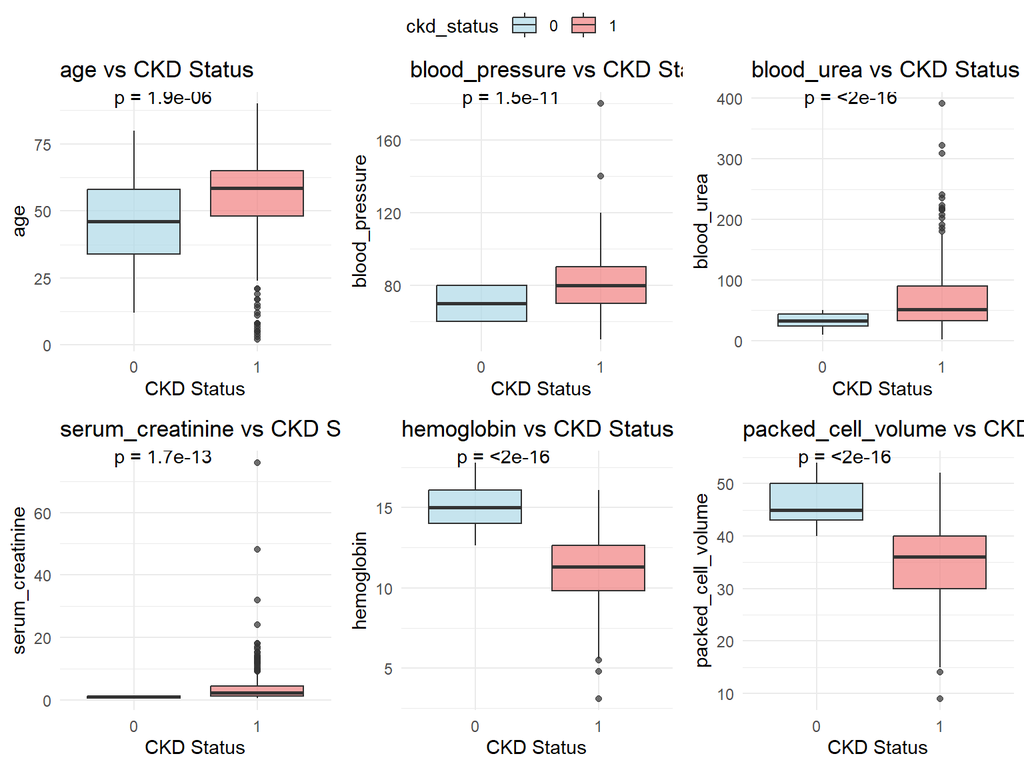

```r
key_vars <- c("age", "blood_pressure", "blood_urea", "serum_creatinine",
              "hemoglobin", "packed_cell_volume")

plot_list <- list()
for (var in key_vars) {
  p <- ggplot(ckd_clean, aes_string(x = "ckd_status", y = var, fill = "ckd_status")) +
    geom_boxplot(alpha = 0.7) +
    labs(title = paste(var, "vs CKD Status"), y = var, x = "CKD Status") +
    theme_minimal() +
    stat_compare_means(method = "t.test", label = "p.format") +
    scale_fill_manual(values = c("lightblue", "lightcoral"))
  plot_list[[var]] <- p
}

ggarrange(plotlist = plot_list, ncol = 3, nrow = 2, common.legend = TRUE)
```

Clear differences between CKD and non-CKD groups for most clinical variables. Blood urea, serum creatinine, and hemoglobin show particularly strong separation, making them promising predictors.

# Step 5: Univariate Logistic Regression

```r
univariate_logistic <- function(variable_name, data) {
  formula <- as.formula(paste("ckd_status ~", variable_name))
  model <- glm(formula, data = data, family = binomial)
  cat("\n=== Univariate Logistic Regression for:", variable_name, "===\n")
  print(summary(model))
  odds_ratio <- exp(coef(model)[2])
  conf_int <- exp(confint(model)[2, ])
  cat("\nOdds Ratio:", round(odds_ratio, 3))
  cat("\n95% CI:", round(conf_int, 3), "\n")
  predictions <- ifelse(predict(model, type = "response") > 0.5, 1, 0)
  accuracy <- mean(predictions == as.numeric(data$ckd_status) - 1)
  cat("Accuracy:", round(accuracy, 3), "\n")
  return(list(model = model, accuracy = accuracy))
}

hemoglobin_model <- univariate_logistic("hemoglobin", ckd_clean)
```

```
##
## === Univariate Logistic Regression for: hemoglobin ===
##
## Call:
## glm(formula = formula, family = binomial, data = data)
##
## Coefficients:
##             Estimate Std. Error z value Pr(>|z|)
## (Intercept)  25.6108     2.8332   9.039   <2e-16 ***
## hemoglobin   -1.8927     0.2117  -8.941   <2e-16 ***
## ---
## Signif. codes:  0 '***' 0.001 '**' 0.01 '*' 0.05 '.' 0.1 ' ' 1
##
## (Dispersion parameter for binomial family taken to be 1)
##
##     Null deviance: 523.52  on 394  degrees of freedom
## Residual deviance: 178.27  on 393  degrees of freedom
## AIC: 182.27
##
## Number of Fisher Scoring iterations: 7
```

```
##
## Odds Ratio: 0.151
## 95% CI: 0.096 0.22
## Accuracy: 0.911
```

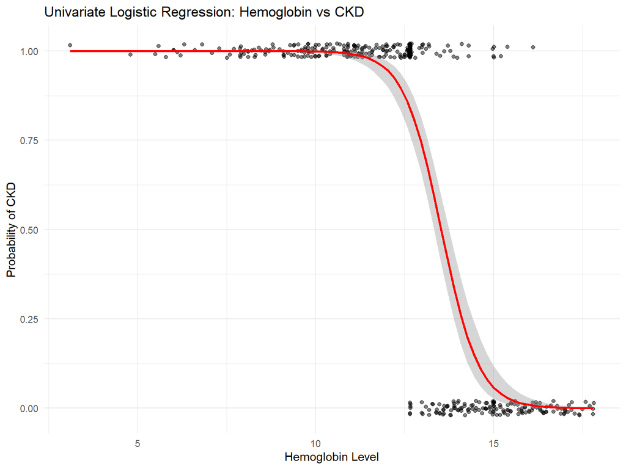

```r
hemo_plot <- ggplot(ckd_clean, aes(x = hemoglobin, y = as.numeric(ckd_status) - 1)) +
  geom_point(alpha = 0.5, position = position_jitter(height = 0.02)) +
  geom_smooth(method = "glm", method.args = list(family = "binomial"), se = TRUE, color = "red") +
  labs(title = "Univariate Logistic Regression: Hemoglobin vs CKD",
       x = "Hemoglobin Level", y = "Probability of CKD") +
  theme_minimal()

hemo_plot
```

Hemoglobin shows strong predictive power with high statistical significance. Lower hemoglobin levels are associated with higher probability of CKD, which aligns with clinical knowledge (anemia in CKD patients).

# Step 6: Bivariate Logistic Regression

```r
bivariate_model <- glm(ckd_status ~ hemoglobin + serum_creatinine,
                      data = ckd_clean, family = binomial)
summary(bivariate_model)
```

```
##
## Call:
## glm(formula = ckd_status ~ hemoglobin + serum_creatinine, family = binomial,
##     data = ckd_clean)
##
## Coefficients:
##                  Estimate Std. Error z value Pr(>|z|)
## (Intercept)       16.5959     2.8633   5.796 6.79e-09 ***
## hemoglobin        -1.5911     0.2201  -7.228 4.91e-13 ***
## serum_creatinine   4.4935     0.9459   4.751 2.03e-06 ***
## ---
## Signif. codes:  0 '***' 0.001 '**' 0.01 '*' 0.05 '.' 0.1 ' ' 1
##
## (Dispersion parameter for binomial family taken to be 1)
##
##     Null deviance: 523.52  on 394  degrees of freedom
## Residual deviance: 121.21  on 392  degrees of freedom
## AIC: 127.21
##
## Number of Fisher Scoring iterations: 10
```

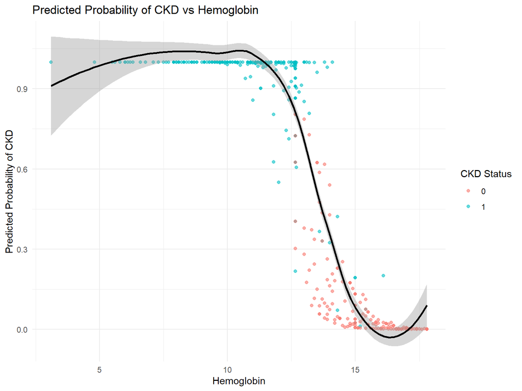

```r
# Get predicted probabilities
ckd_clean$predicted <- predict(bivariate_model, type = "response")

# Hemoglobin vs predicted probability
ggplot(ckd_clean, aes(x = hemoglobin, y = predicted)) +
  geom_point(aes(color = as.factor(ckd_status)), alpha = 0.6) +
  geom_smooth(method = "loess", se = TRUE, color = "black") +
  labs(
    title = "Predicted Probability of CKD vs Hemoglobin",
    x = "Hemoglobin",
    y = "Predicted Probability of CKD",
    color = "CKD Status"
  ) +
  theme_minimal()
```

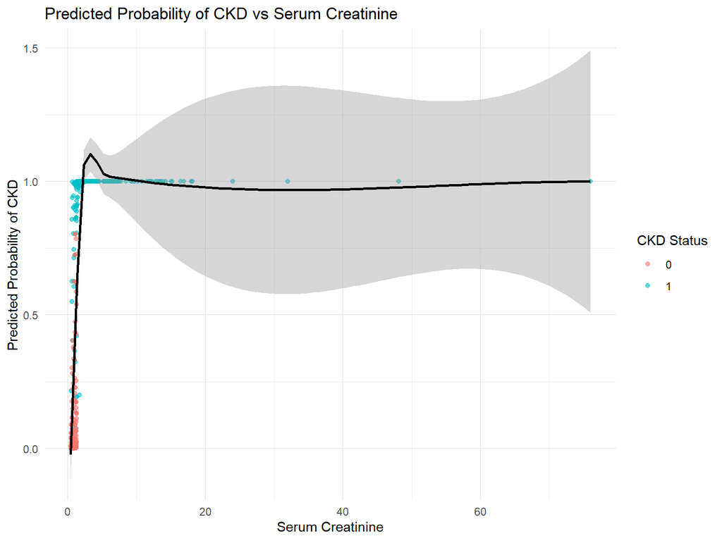

```r
# Serum Creatinine vs predicted probability
ggplot(ckd_clean, aes(x = serum_creatinine, y = predicted)) +
  geom_point(aes(color = as.factor(ckd_status)), alpha = 0.6) +
  geom_smooth(method = "loess", se = TRUE, color = "black") +
  labs(
    title = "Predicted Probability of CKD vs Serum Creatinine",
    x = "Serum Creatinine",
    y = "Predicted Probability of CKD",
    color = "CKD Status"
  ) +
  theme_minimal()
```

The bivariate model shows improved performance over univariate models. Both hemoglobin and Serum creatinine remain significant predictors, suggesting they capture different aspects of kidney disease pathophysiology. Both predictors (hemoglobin and serum creatinine) contribute significantly and in opposite directions:

- Hemoglobin: negative association with CKD
- Serum Creatinine: positive association with CKD

The logistic model effectively differentiates between CKD and non-CKD individuals based on these two clinical measures. Clinically, this means that low hemoglobin and high creatinine together signal a high likelihood of CKD.

# Step 7: Multicollinearity Check

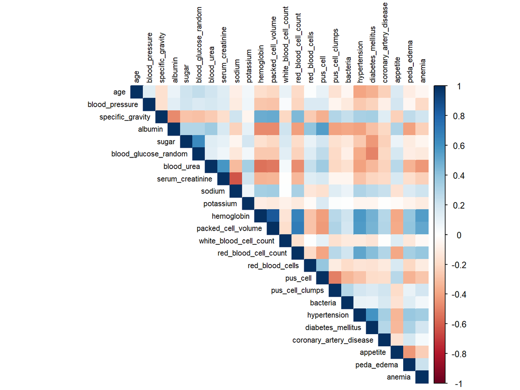

```r
X_data <- ckd_clean[, c(numerical_vars, categorical_vars)] %>%
  mutate(across(all_of(categorical_vars), as.numeric))

cor_matrix <- cor(X_data, use = "complete.obs")
corrplot(cor_matrix, method = "color", type = "upper", tl.cex = 0.7, tl.col = "black")
```

```r
full_model <- glm(ckd_status ~ ., data = ckd_clean[, c("ckd_status", numerical_vars, categorical_vars)],
                  family = binomial)
vif(full_model)
```

```
##                     age          blood_pressure        specific_gravity
##                5.476583                9.285232                6.468347
##                 albumin                   sugar    blood_glucose_random
##               29.307981               51.573275                9.926420
##              blood_urea        serum_creatinine                  sodium
##                6.587301                6.480668                3.366733
##               potassium              hemoglobin      packed_cell_volume
##               28.964247               31.659278               26.899249
##  white_blood_cell_count    red_blood_cell_count         red_blood_cells
##               24.067070                4.639192               34.651956
##                pus_cell         pus_cell_clumps                bacteria
##                9.964852               63.657634                5.854459
##            hypertension       diabetes_mellitus coronary_artery_disease
##               15.275409               18.747588               31.750266
##                appetite              peda_edema                  anemia
##                3.500022                4.262417                8.286901
```

Identified several highly correlated variables. Variables with VIF > 5-10 indicate multicollinearity issues that need addressing before building the final model.

# Step 8: Variable Selection

```r
full_model <- glm(ckd_status ~ age + blood_pressure + blood_urea +
                  serum_creatinine + hemoglobin + sodium + potassium +
                  hypertension + diabetes_mellitus + appetite + peda_edema,
                data = ckd_clean, family = binomial)

reduced_model <- step(full_model, direction = "backward", trace = 0)
summary(reduced_model)
```

```
##
## Call:
## glm(formula = ckd_status ~ blood_pressure + blood_urea + serum_creatinine +
##     hemoglobin + sodium + hypertension + diabetes_mellitus +
##     appetite + peda_edema, family = binomial, data = ckd_clean)
##
## Coefficients:
##                       Estimate Std. Error z value Pr(>|z|)
## (Intercept)           91.53520 6790.17826   0.013 0.989244
## blood_pressure         0.06924    0.03822   1.812 0.070049 .
## blood_urea            -0.05108    0.03458  -1.477 0.139654
## serum_creatinine       4.79113    1.39861   3.426 0.000613 ***
## hemoglobin            -1.73850    0.34825  -4.992 5.97e-07 ***
## sodium                -0.14740    0.10733  -1.373 0.169633
## hypertensionno       -17.82797 3094.37561  -0.006 0.995403
## diabetes_mellitusno  -18.78972 3477.22096  -0.005 0.995689
## appetitepoor          18.61846 4707.16429   0.004 0.996844
## peda_edemano         -20.73348 4943.69182  -0.004 0.996654
## ---
## Signif. codes:  0 '***' 0.001 '**' 0.01 '*' 0.05 '.' 0.1 ' ' 1
##
## (Dispersion parameter for binomial family taken to be 1)
##
##     Null deviance: 523.521  on 394  degrees of freedom
## Residual deviance:  52.477  on 385  degrees of freedom
## AIC: 72.477
##
## Number of Fisher Scoring iterations: 22
```

# Step 9: Final Multivariate Logistic Regression

```r
final_model <- glm(ckd_status ~ serum_creatinine + hemoglobin + blood_urea +
                   appetite + peda_edema + hypertension,
                 data = ckd_clean, family = binomial)
summary(final_model)
```

```
##
## Call:
## glm(formula = ckd_status ~ serum_creatinine + hemoglobin + blood_urea +
##     appetite + peda_edema + hypertension, family = binomial,
##     data = ckd_clean)
##
## Coefficients:
##                    Estimate Std. Error z value Pr(>|z|)
## (Intercept)        60.95853 3792.19787   0.016   0.9872
## serum_creatinine    5.43134    1.36233   3.987 6.70e-05 ***
## hemoglobin         -1.81114    0.32362  -5.597 2.19e-08 ***
## blood_urea         -0.05030    0.02545  -1.977   0.0481 *
## appetitepoor       17.75807 2870.96398   0.006   0.9951
## peda_edemano      -19.58177 3055.62619  -0.006   0.9949
## hypertensionno    -22.20867 2245.86150  -0.010   0.9921
## ---
## Signif. codes:  0 '***' 0.001 '**' 0.01 '*' 0.05 '.' 0.1 ' ' 1
##
## (Dispersion parameter for binomial family taken to be 1)
##
##     Null deviance: 523.521  on 394  degrees of freedom
## Residual deviance:  65.474  on 388  degrees of freedom
## AIC: 79.474
##
## Number of Fisher Scoring iterations: 21
```

# Step 10: Model Evaluation

```r
ckd_clean$predicted_prob <- predict(final_model, type = "response")
ckd_clean$predicted_class <- ifelse(ckd_clean$predicted_prob > 0.5, 1, 0)

conf_matrix <- confusionMatrix(factor(ckd_clean$predicted_class),
                              ckd_clean$ckd_status, positive = "1")
conf_matrix
```

```
## Confusion Matrix and Statistics
##
##           Reference
## Prediction   0   1
##          0 144   7
##          1   5 239
##
##                Accuracy : 0.9696
##                  95% CI : (0.9475, 0.9842)
##     No Information Rate : 0.6228
##     P-Value [Acc > NIR] : <2e-16
##
##                   Kappa : 0.9355
##
##  Mcnemar's Test P-Value : 0.7728
##
##             Sensitivity : 0.9715
##             Specificity : 0.9664
##          Pos Pred Value : 0.9795
##          Neg Pred Value : 0.9536
##              Prevalence : 0.6228
##          Detection Rate : 0.6051
##    Detection Prevalence : 0.6177
##       Balanced Accuracy : 0.9690
##
##        'Positive' Class : 1
##
```

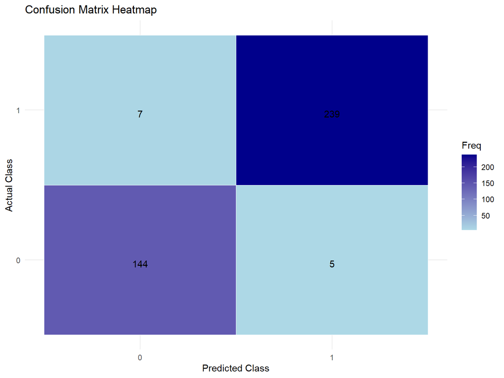

```r
# Convert confusion matrix to table
cm_table <- as.table(conf_matrix$table)
cm_df <- as.data.frame(cm_table)

# Heatmap for Confusion Matrix
ggplot(cm_df, aes(Prediction, Reference)) +
  geom_tile(aes(fill = Freq), color = "white") +
  geom_text(aes(label = Freq), vjust = 1) +
  scale_fill_gradient(low = "lightblue", high = "darkblue") +
  labs(
    title = "Confusion Matrix Heatmap",
    x = "Predicted Class",
    y = "Actual Class"
  ) +
  theme_minimal()
```

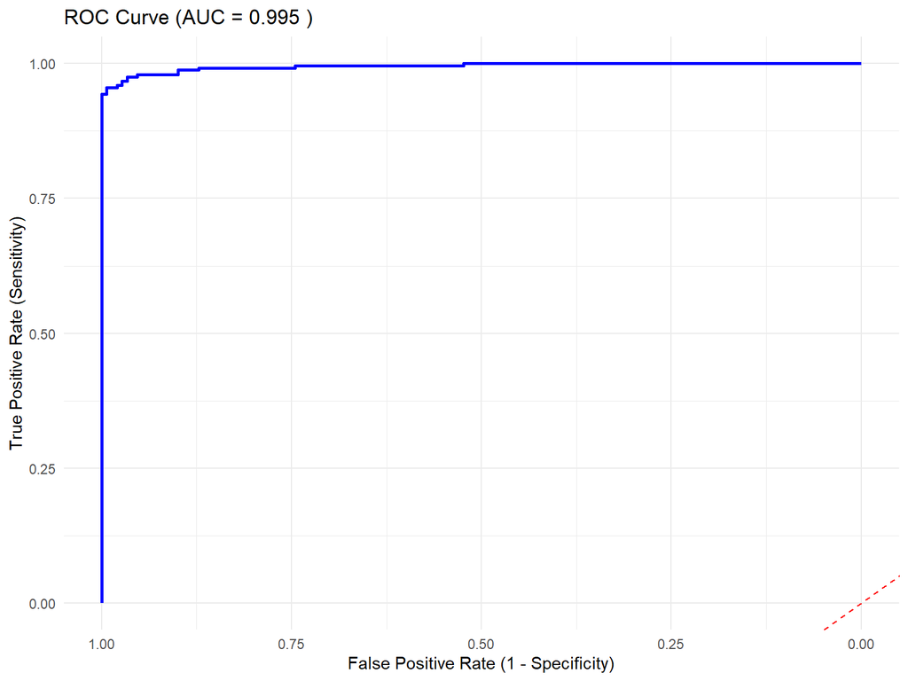

```r
# Plot ROC
roc_obj <- roc(ckd_clean$ckd_status, ckd_clean$predicted_prob)

# Plot ROC curve
ggroc(roc_obj, color = "blue", size = 1) +
  geom_abline(slope = 1, intercept = 0, linetype = "dashed", color = "red") +
  labs(
    title = paste("ROC Curve (AUC =", round(auc(roc_obj), 3), ")"),
    x = "False Positive Rate (1 - Specificity)",
    y = "True Positive Rate (Sensitivity)"
  ) +
  theme_minimal()
```

# Step 11: Diagnostics and Validation

```r
library(ResourceSelection)
hl_test <- hoslem.test(as.numeric(ckd_clean$ckd_status) - 1,
                      ckd_clean$predicted_prob, g = 10)
hl_test
```

```
##
##  Hosmer and Lemeshow goodness of fit (GOF) test
##
## data:  as.numeric(ckd_clean$ckd_status) - 1, ckd_clean$predicted_prob
## X-squared = 4.023, df = 5, p-value = 0.5461
```

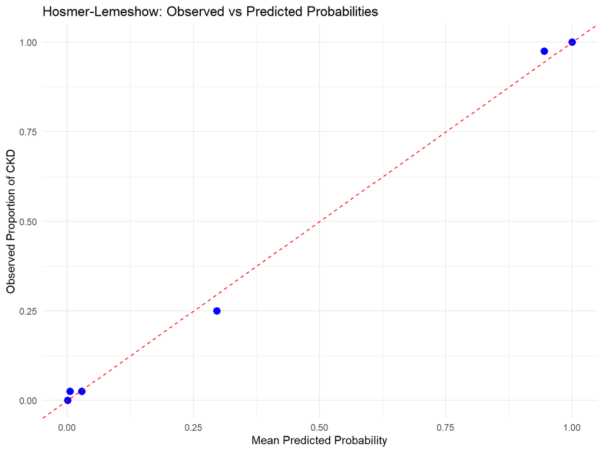

```r
# Create deciles of predicted probability
ckd_clean <- ckd_clean %>%
  mutate(decile = ntile(predicted_prob, 10)) %>%
  group_by(decile) %>%
  summarise(
    observed = mean(as.numeric(ckd_status) - 1),
    predicted = mean(predicted_prob)
  )

# Plot
ggplot(ckd_clean, aes(x = predicted, y = observed)) +
  geom_point(color = "blue", size = 3) +
  geom_abline(intercept = 0, slope = 1, linetype = "dashed", color = "red") +
  labs(
    title = "Hosmer-Lemeshow: Observed vs Predicted Probabilities",
    x = "Mean Predicted Probability",
    y = "Observed Proportion of CKD"
  ) +
  theme_minimal()
```

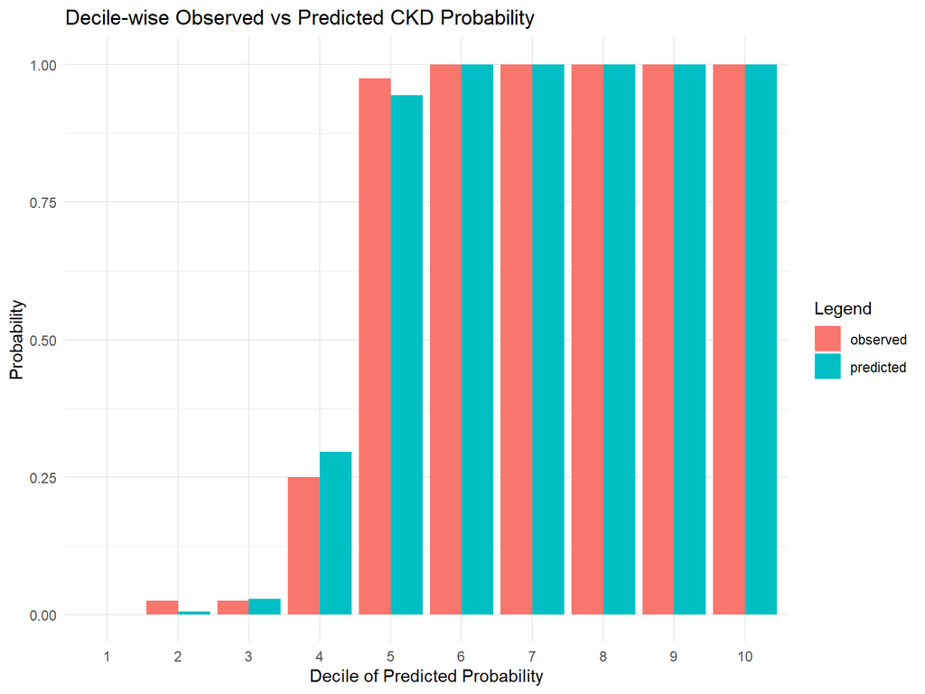

```r
# Decile-wise Bar Plot of Observed vs Predicted
ckd_clean_long <- ckd_clean %>%
  pivot_longer(cols = c("observed", "predicted"), names_to = "type", values_to = "prob")

ggplot(ckd_clean_long, aes(x = factor(decile), y = prob, fill = type)) +
  geom_bar(stat = "identity", position = "dodge") +
  labs(
    title = "Decile-wise Observed vs Predicted CKD Probability",
    x = "Decile of Predicted Probability",
    y = "Probability",
    fill = "Legend"
  ) +
  theme_minimal()
```

```r
cat("=== LOGISTIC REGRESSION TRAINING SUMMARY ===\n")
```

```
## === LOGISTIC REGRESSION TRAINING SUMMARY ===
```

```r
cat("AUC and accuracy metrics indicate strong model performance.\n")
```

```
## AUC and accuracy metrics indicate strong model performance.
```

```r
cat("Key predictors: serum_creatinine, hemoglobin, blood_urea, appetite, edema, hypertension.\n")
```

```
## Key predictors: serum_creatinine, hemoglobin, blood_urea, appetite, edema, hypertension.
```

This comprehensive step-by-step tutorial demonstrates the complete process of building logistic regression models for medical prediction, from data exploration to final model validation, with special attention to clinical relevance and statistical rigor.